# exercise-11

2024-03-30

## Preliminaries

- Set up a new GitHub repo in your GitHub workspace named “exercise-11” and clone that down to your computer as a new RStudio project. The instructions outlined as Method 1 in Module 6 will be helpful
- Using the {tidyverse} read_csv() function, load the “AVONETdataset1.csv” dataset from this URL as a “tibble” named d. As discussed in class, this is a recently published dataset that compiles morphological measurements and information on various ecological variables and geographic range data for more than 11,000 species of birds.
- Winnow the dataset to include only the following variables: Species1, Family1, Order1, Beak.Length_Culmen, Beak.Width, Beak.Depth, Tarsus.Length, Wing.Length, Tail.Length, Mass, Habitat, Migration, Trophic.Level, Trophic.Niche, Min.Latitude, Max.Latitude, Centroid.Latitude, Primary.Lifestyle, ** and Range.Size
- Do a bit of exploratory data analysis with this dataset, e.g., using the {skimr} package. Which of the variables are categorical and which are numeric?
  - Categorical variables (from {skimr}): Species1, Family1, Order1, Habitat, Trophic.Level, Trophic.Niche, Primary.Lifestyle.
  - Numberic variables: Beak.Length_Culmen, Beak.Width, Beak.Depth, Tarsus.Length, Wing.Length, Tail.Length, Mass, Migration, Min.Latitude, Max.Latitude, Centroid.Latitude, Range.Size

```r
# Set up libraries
library(tidyverse)
library(skimr)
library(cowplot)
library(tidyr)
library(broom)
library(infer)
```

```r
f <- "https://raw.githubusercontent.com/difiore/ada-2024-datasets/main/AVONETdataset1.csv"
d <- read_csv(f, col_names = TRUE)
# Winnow the data set to include specific variables...

d <- d %>%
  select(Species1, Family1, Order1, Beak.Length_Culmen, Beak.Width, Beak.Depth,
        Tarsus.Length, Wing.Length, Tail.Length, Mass, Habitat, Migration,
        Trophic.Level, Trophic.Niche, Min.Latitude, Max.Latitude,
        Centroid.Latitude, Primary.Lifestyle, Range.Size)

# Explorin'
glimpse(d)
```

```
## Rows: 11,009
## Columns: 19
## $ Species1           <chr> "Accipiter albogularis", "Accipiter badius", "Accip…
## $ Family1            <chr> "Accipitridae", "Accipitridae", "Accipitridae", "Ac…
## $ Order1             <chr> "Accipitriformes", "Accipitriformes", "Accipitrifor…
## $ Beak.Length_Culmen <dbl> 27.7, 20.6, 25.0, 22.5, 21.1, 20.0, 20.5, 19.2, 20.…
## $ Beak.Width         <dbl> 10.6, 8.8, 8.6, 8.9, 8.7, 6.6, 8.3, 7.7, 8.6, 8.6, …
## $ Beak.Depth         <dbl> 14.7, 11.6, 12.7, 11.9, 11.1, 12.0, 10.9, 9.6, 11.0…
## $ Tarsus.Length      <dbl> 62.0, 43.0, 58.1, 61.2, 46.4, 48.7, 52.6, 60.3, 43.…
## $ Wing.Length        <dbl> 235.2, 186.7, 229.6, 202.2, 217.6, 166.0, 163.5, 21…
## $ Tail.Length        <dbl> 169.0, 140.6, 186.3, 140.8, 153.5, 127.0, 135.4, 15…
## $ Mass               <dbl> 248.8, 131.2, 287.5, 142.0, 186.5, 122.0, 157.5, 16…
## $ Habitat            <chr> "Forest", "Shrubland", "Woodland", "Forest", "Fores…
## $ Migration          <dbl> 2, 3, 2, 2, 3, 1, 2, 2, 2, 3, 1, 1, 1, 1, 2, 1, 3, …
## $ Trophic.Level      <chr> "Carnivore", "Carnivore", "Carnivore", "Carnivore",…
## $ Trophic.Niche      <chr> "Vertivore", "Vertivore", "Vertivore", "Vertivore",…
## $ Min.Latitude       <dbl> -11.73, -29.47, -55.72, -6.31, 31.19, 7.87, -10.36,…
## $ Max.Latitude       <dbl> -4.02, 46.39, 23.73, -4.08, 55.86, 9.26, 10.12, 0.0…
## $ Centroid.Latitude  <dbl> -8.15, 8.23, -10.10, -5.45, 45.24, 8.42, 0.71, -23.…
## $ Primary.Lifestyle  <chr> "Insessorial", "Insessorial", "Generalist", "Insess…
## $ Range.Size         <dbl> 37461.21, 22374973.00, 14309701.27, 35580.71, 29367…
```

```r
skim(d)
```

Data summary

| Name | d |
| --- | --- |
| Number of rows | 11009 |
| Number of columns | 19 |
| _______________________ |  |
| Column type frequency: |  |
| character | 7 |
| numeric | 12 |
| ________________________ |  |
| Group variables | None |

**Variable type: character**

| skim_variable | n_missing | complete_rate | min | max | empty | n_unique | whitespace |
| --- | --- | --- | --- | --- | --- | --- | --- |
| Species1 | 0 | 1.00 | 9 | 36 | 0 | 11009 | 0 |
| Family1 | 0 | 1.00 | 7 | 18 | 0 | 243 | 0 |
| Order1 | 0 | 1.00 | 10 | 19 | 0 | 36 | 0 |
| Habitat | 98 | 0.99 | 4 | 14 | 0 | 11 | 0 |
| Trophic.Level | 5 | 1.00 | 8 | 9 | 0 | 4 | 0 |
| Trophic.Niche | 10 | 1.00 | 8 | 21 | 0 | 10 | 0 |
| Primary.Lifestyle | 0 | 1.00 | 6 | 11 | 0 | 5 | 0 |

**Variable type: numeric**

| skim_variable | n_missing | complete_rate | mean | sd | p0 | p25 | p50 | p75 | p100 | hist |
| --- | --- | --- | --- | --- | --- | --- | --- | --- | --- | --- |
| Beak.Length_Culmen | 0 | 1.00 | 26.36 | 24.39 | 4.50 | 14.70 | 19.90 | 28.50 | 414.20 | ▇▁▁▁▁ |
| Beak.Width | 0 | 1.00 | 6.58 | 5.15 | 0.70 | 3.60 | 5.00 | 7.70 | 88.90 | ▇▁▁▁▁ |
| Beak.Depth | 0 | 1.00 | 8.06 | 7.59 | 1.00 | 3.80 | 5.80 | 9.40 | 110.90 | ▇▁▁▁▁ |
| Tarsus.Length | 0 | 1.00 | 28.73 | 24.84 | 2.50 | 17.40 | 22.00 | 31.30 | 481.20 | ▇▁▁▁▁ |
| Wing.Length | 0 | 1.00 | 124.78 | 93.44 | 0.10 | 66.80 | 91.50 | 145.50 | 789.90 | ▇▂▁▁▁ |
| Tail.Length | 0 | 1.00 | 86.65 | 61.08 | 0.10 | 50.20 | 68.70 | 99.90 | 812.80 | ▇▁▁▁▁ |
| Mass | 0 | 1.00 | 267.15 | 1883.03 | 1.90 | 15.00 | 35.50 | 121.00 | 111000.00 | ▇▁▁▁▁ |
| Migration | 23 | 1.00 | 1.29 | 0.62 | 1.00 | 1.00 | 1.00 | 1.00 | 3.00 | ▇▁▁▁▁ |
| Min.Latitude | 57 | 0.99 | -6.44 | 22.37 | -85.58 | -21.22 | -7.15 | 8.07 | 68.08 | ▁▃▇▃▁ |
| Max.Latitude | 57 | 0.99 | 11.51 | 23.32 | -65.12 | -3.33 | 9.00 | 22.07 | 85.01 | ▁▃▇▂▁ |
| Centroid.Latitude | 57 | 0.99 | 2.95 | 22.07 | -71.04 | -9.73 | -0.22 | 15.28 | 78.43 | ▁▃▇▂▁ |
| Range.Size | 57 | 0.99 | 2578859.38 | 7629310.06 | 0.88 | 54052.87 | 416076.61 | 2187040.21 | 136304432.20 | ▇▁▁▁▁ |

## Challenge 1

#### Step 1

- Make boxplots of log(Mass) in relation to Trophic.Level and Migration behavior type. For each plot, drop from the visualization all species records where the categorical variable of interest is missing from the dataset. Also, you will want to convert the variable Migration (which is scored as a number: “1”, “2”, or “3”) from class numeric to either being classified as a factor or as a character (string) variable.

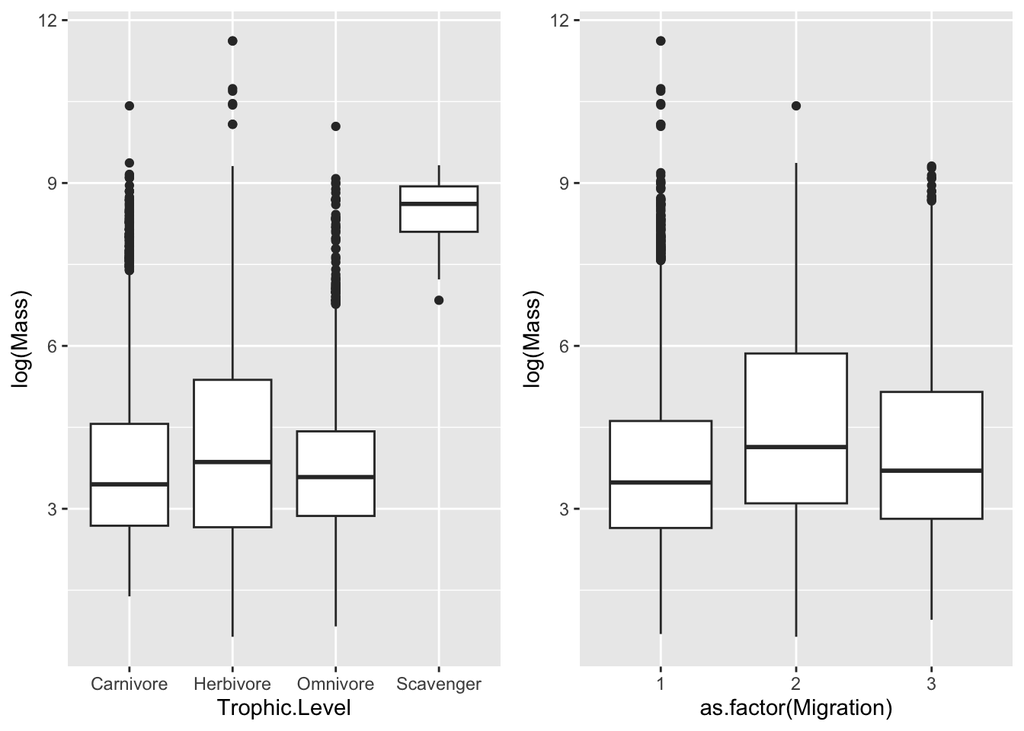

```r
# Add variables of interest to dataset d
d <- d %>%
    mutate(logMass = log(Mass), logRS = log(Range.Size), logBeak = log(Beak.Length_Culmen),
        logTarsus = log(Tarsus.Length), Migration = as.factor(Migration))

# Make boxplots
Box_LogMass_Trophic.Level <- ggplot(data = d %>%
    drop_na(Trophic.Level), aes(x = Trophic.Level, y = log(Mass))) + geom_boxplot()

Box_LogMass_Migration <- ggplot(data = d %>%
    drop_na(Migration), aes(x = as.factor(Migration), y = log(Mass))) + geom_boxplot()

plot_grid(Box_LogMass_Trophic.Level, Box_LogMass_Migration, nrow = 1)
```

#### Step 2

- Run linear models using the lm() function to look at the relationship between log(Mass) and Trophic.Level and between log(Mass) and Migration.
- Examine the output of the resultant linear models. Is log(Mass) associated with either Trophic.Level or Migration category? That is, in the global test of significance, is the F statistic large enough to reject the null hypothesis of an F value of zero?
  - log(Mass) is associated with both Trophic.Level and Migration as the F statistic is large enough to reject the null hypothesis (p <2 .2e-16 for both)
- Given the regression coefficients returned for your Migration model, which Migration categor(ies) are different than the reference level? What level is the reference level? Relevel and assess differences among the remaining pair of Migration categories.
  - In the migration model, the reference level is migration “1”. Both migration “2” and migration “3” are different from migration 1.
  - Regardless of reference level, all levels are different from one another.

```r
# Run linear model
m1 <- lm(data = d, logMass ~ Trophic.Level)
m2 <- lm(data = d, logMass ~ Migration)

# ... and examine outputs
summary(m1)
```

```
##
## Call:
## lm(formula = logMass ~ Trophic.Level, data = d)
##
## Residuals:
##     Min      1Q  Median      3Q     Max
## -3.4229 -1.1551 -0.3028  0.8982  7.5526
##
## Coefficients:
##                        Estimate Std. Error t value Pr(>|t|)
## (Intercept)             3.80834    0.01967 193.632  < 2e-16 ***
## Trophic.LevelHerbivore  0.25639    0.03406   7.528 5.54e-14 ***
## Trophic.LevelOmnivore   0.01422    0.04116   0.345     0.73
## Trophic.LevelScavenger  4.63189    0.34447  13.446  < 2e-16 ***
## ---
## Signif. codes:  0 '***' 0.001 '**' 0.01 '*' 0.05 '.' 0.1 ' ' 1
##
## Residual standard error: 1.538 on 11000 degrees of freedom
##   (5 observations deleted due to missingness)
## Multiple R-squared:  0.02094,    Adjusted R-squared:  0.02067
## F-statistic: 78.42 on 3 and 11000 DF,  p-value: < 2.2e-16
```

```r
summary(m2)
```

```
##
## Call:
## lm(formula = logMass ~ Migration, data = d)
##
## Residuals:
##     Min      1Q  Median      3Q     Max
## -3.8924 -1.1769 -0.3088  0.9152  7.8427
##
## Coefficients:
##             Estimate Std. Error t value Pr(>|t|)
## (Intercept)  3.77457    0.01636 230.710  < 2e-16 ***
## Migration2   0.75971    0.04731  16.059  < 2e-16 ***
## Migration3   0.37647    0.05155   7.303 3.02e-13 ***
## ---
## Signif. codes:  0 '***' 0.001 '**' 0.01 '*' 0.05 '.' 0.1 ' ' 1
##
## Residual standard error: 1.535 on 10983 degrees of freedom
##   (23 observations deleted due to missingness)
## Multiple R-squared:  0.02563,    Adjusted R-squared:  0.02546
## F-statistic: 144.5 on 2 and 10983 DF,  p-value: < 2.2e-16
```

```r
# Relevel and assess
# ... migration level 2 as the reference
d <- d %>%
    mutate(Migration = relevel(Migration, ref = "2"))
m3 <- lm(logMass ~ Migration, data = d)
summary(m3)
```

```
##
## Call:
## lm(formula = logMass ~ Migration, data = d)
##
## Residuals:
##     Min      1Q  Median      3Q     Max
## -3.8924 -1.1769 -0.3088  0.9152  7.8427
##
## Coefficients:
##             Estimate Std. Error t value Pr(>|t|)
## (Intercept)  4.53428    0.04439 102.149  < 2e-16 ***
## Migration1  -0.75971    0.04731 -16.059  < 2e-16 ***
## Migration3  -0.38324    0.06603  -5.804 6.67e-09 ***
## ---
## Signif. codes:  0 '***' 0.001 '**' 0.01 '*' 0.05 '.' 0.1 ' ' 1
##
## Residual standard error: 1.535 on 10983 degrees of freedom
##   (23 observations deleted due to missingness)
## Multiple R-squared:  0.02563,    Adjusted R-squared:  0.02546
## F-statistic: 144.5 on 2 and 10983 DF,  p-value: < 2.2e-16
```

```r
# ... migration level 3 as the reference
d <- d %>%
    mutate(Migration = relevel(Migration, ref = "3"))
m4 <- lm(logMass ~ Migration, data = d)
summary(m4)
```

```
##
## Call:
## lm(formula = logMass ~ Migration, data = d)
##
## Residuals:
##     Min      1Q  Median      3Q     Max
## -3.8924 -1.1769 -0.3088  0.9152  7.8427
##
## Coefficients:
##             Estimate Std. Error t value Pr(>|t|)
## (Intercept)  4.15104    0.04889  84.909  < 2e-16 ***
## Migration2   0.38324    0.06603   5.804 6.67e-09 ***
## Migration1  -0.37647    0.05155  -7.303 3.02e-13 ***
## ---
## Signif. codes:  0 '***' 0.001 '**' 0.01 '*' 0.05 '.' 0.1 ' ' 1
##
## Residual standard error: 1.535 on 10983 degrees of freedom
##   (23 observations deleted due to missingness)
## Multiple R-squared:  0.02563,    Adjusted R-squared:  0.02546
## F-statistic: 144.5 on 2 and 10983 DF,  p-value: < 2.2e-16
```

#### Step 3

- Conduct a post-hoc Tukey Honest Significant Differences test to also evaluate which Migration categories differ “significantly” from one another
  - Tukey HSD estimates the difference between the means of groups and calculates the 95% confidence interval for the difference between the corresponding populations. The p-value from a test of the null hypothesis of no difference between the means (p adj). Here, p value is (apparently 0), so we can conclude that the migration levels are signficantly different from each other. (lwr = lower bound of the confidence interval; upr = upper bound of the confidence interval; donfidence intervals that cross the vertical line indicate pairs of groups where the difference in mean is not significant)

```r
# Run ANOVA analysis for Tukey
logMass_Migration_ANOVA <- aov(data = d, logMass ~ Migration)

# Tukey!
logMass_Migration_Tukey <- TukeyHSD(logMass_Migration_ANOVA, which = "Migration", conf.level = 0.95)
logMass_Migration_Tukey
```

```
##   Tukey multiple comparisons of means
##     95% family-wise confidence level
##
## Fit: aov(formula = logMass ~ Migration, data = d)
##
## $Migration
##           diff        lwr        upr p adj
## 2-3  0.3832374  0.2284536  0.5380211     0
## 1-3 -0.3764693 -0.4973105 -0.2556282     0
## 1-2 -0.7597067 -0.8705977 -0.6488157     0
```

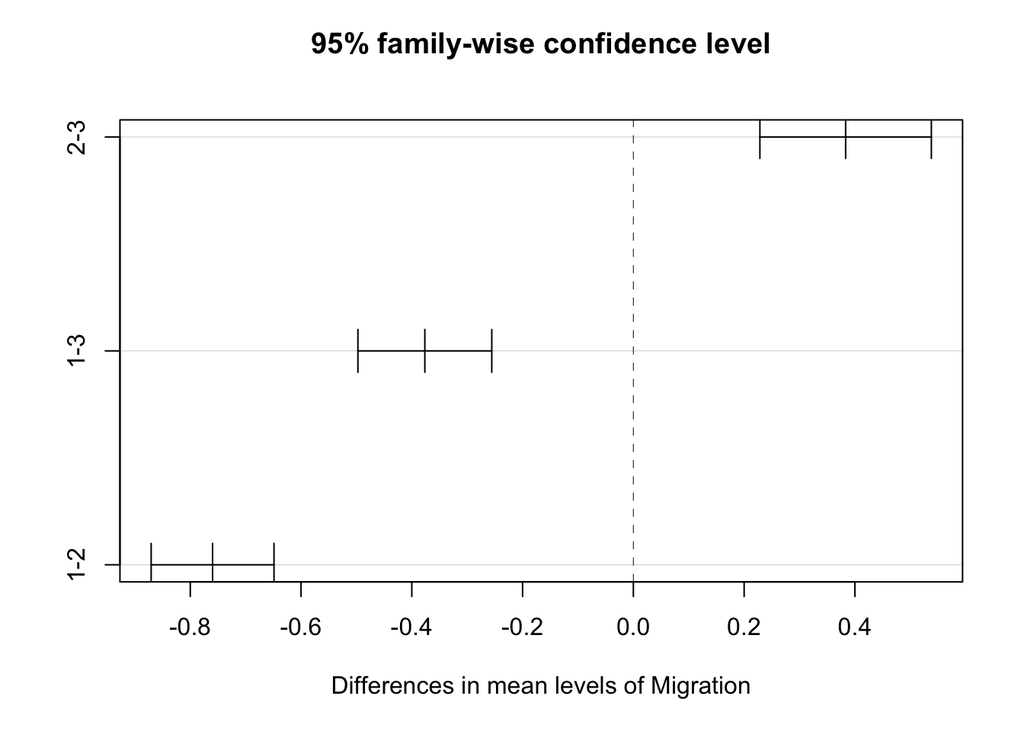

```r
plot(logMass_Migration_Tukey)
```

#### Step 4

- Use a permutation approach to inference to generate a null distribution of F statistic values for the model of log(Mass) in relation to Trophic.Level and calculate a p value for your original F statistic. You can do this either by programming your own permutation test (e.g., by shuffling values for the predictor or response variable among observations and calculating an F statistic for each replicate) or by using the {infer} workflow and setting calculate(stat=“F”).

```r
# Get F statistic, then using Module 18 Simulation-Based Inference for the permutation approach
# Getting F stat
original.Fstat <- aov(logMass ~ Trophic.Level, data = d) %>%
    tidy() %>%
    filter(term == "Trophic.Level") %>%
    pull(statistic)
original.Fstat
```

```
## [1] 78.42283
```

```r
# Here's where module 18 comes in
# Yay infer
permuted.Fstat <- d %>%
    specify(logMass ~ Trophic.Level) %>%
    hypothesize(null = "independence") %>%
    generate(reps = 1000, type = "permute") %>%
    calculate(stat = "F")
# Let's see those first 6 permutation replicated
head(permuted.Fstat)
```

```
## Response: logMass (numeric)
## Explanatory: Trophic.Level (factor)
## Null Hypothesis: independence
## # A tibble: 6 × 2
##   replicate  stat
##       <int> <dbl>
## 1         1 0.512
## 2         2 0.513
## 3         3 1.59
## 4         4 0.318
## 5         5 1.15
## 6         6 0.698
```

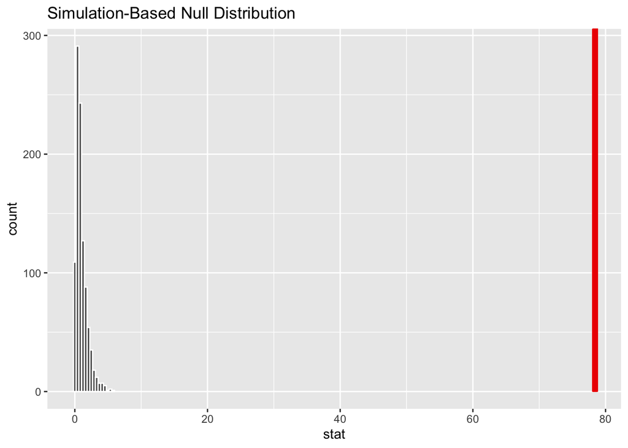

```r
# Plot the null distribution based on permutation using visualize() from {infer}
visualize(permuted.Fstat) + shade_p_value(obs_stat = original.Fstat, direction = "greater") # really far away from the distribution!
```

## Challenge 2

#### Step 1

- Create the following two new variables and add them to AVONET dataset:
  - Relative beak length, which you should calculate as the residual of log(Beak.Length_Culmen) on log(Mass).
  - Relative tarsus length, which you should calculate as the residual of log(Tarsus.Length) on log(Mass).

```r
rel_BL <- lm(logBeak ~ logMass, data = d)
rel_TL <- lm(logTarsus ~ logMass, data = d)

d <- d %>%
    mutate(rel_BL= rel_BL$residuals, rel_TL = rel_TL$residuals)

# Check to make sure those variables are added
glimpse(d)
```

```
## Rows: 11,009
## Columns: 25
## $ Species1           <chr> "Accipiter albogularis", "Accipiter badius", "Accip…
## $ Family1            <chr> "Accipitridae", "Accipitridae", "Accipitridae", "Ac…
## $ Order1             <chr> "Accipitriformes", "Accipitriformes", "Accipitrifor…
## $ Beak.Length_Culmen <dbl> 27.7, 20.6, 25.0, 22.5, 21.1, 20.0, 20.5, 19.2, 20.…
## $ Beak.Width         <dbl> 10.6, 8.8, 8.6, 8.9, 8.7, 6.6, 8.3, 7.7, 8.6, 8.6, …
## $ Beak.Depth         <dbl> 14.7, 11.6, 12.7, 11.9, 11.1, 12.0, 10.9, 9.6, 11.0…
## $ Tarsus.Length      <dbl> 62.0, 43.0, 58.1, 61.2, 46.4, 48.7, 52.6, 60.3, 43.…
## $ Wing.Length        <dbl> 235.2, 186.7, 229.6, 202.2, 217.6, 166.0, 163.5, 21…
## $ Tail.Length        <dbl> 169.0, 140.6, 186.3, 140.8, 153.5, 127.0, 135.4, 15…
## $ Mass               <dbl> 248.8, 131.2, 287.5, 142.0, 186.5, 122.0, 157.5, 16…
## $ Habitat            <chr> "Forest", "Shrubland", "Woodland", "Forest", "Fores…
## $ Migration          <fct> 2, 3, 2, 2, 3, 1, 2, 2, 2, 3, 1, 1, 1, 1, 2, 1, 3, …
## $ Trophic.Level      <chr> "Carnivore", "Carnivore", "Carnivore", "Carnivore",…
## $ Trophic.Niche      <chr> "Vertivore", "Vertivore", "Vertivore", "Vertivore",…
## $ Min.Latitude       <dbl> -11.73, -29.47, -55.72, -6.31, 31.19, 7.87, -10.36,…
## $ Max.Latitude       <dbl> -4.02, 46.39, 23.73, -4.08, 55.86, 9.26, 10.12, 0.0…
## $ Centroid.Latitude  <dbl> -8.15, 8.23, -10.10, -5.45, 45.24, 8.42, 0.71, -23.…
## $ Primary.Lifestyle  <chr> "Insessorial", "Insessorial", "Generalist", "Insess…
## $ Range.Size         <dbl> 37461.21, 22374973.00, 14309701.27, 35580.71, 29367…
## $ logMass            <dbl> 5.516649, 4.876723, 5.661223, 4.955827, 5.228431, 4…
## $ logRS              <dbl> 10.531061, 16.923454, 16.476448, 10.479559, 14.8928…
## $ logBeak            <dbl> 3.321432, 3.025291, 3.218876, 3.113515, 3.049273, 2…
## $ logTarsus          <dbl> 4.127134, 3.761200, 4.062166, 4.114147, 3.837299, 3…
## $ rel_BL             <dbl> -0.2070788, -0.3256851, -0.3497445, -0.2594067, -0.…
## $ rel_TL             <dbl> 0.4639465, 0.2936955, 0.3547687, 0.6224533, 0.26224…
```

#### Step 2

- Make a boxplot or violin plot of your new relative tarsus length variable in relation to Primary.Lifestyle and of your new relative beak length variable in relation to Trophic.Niche

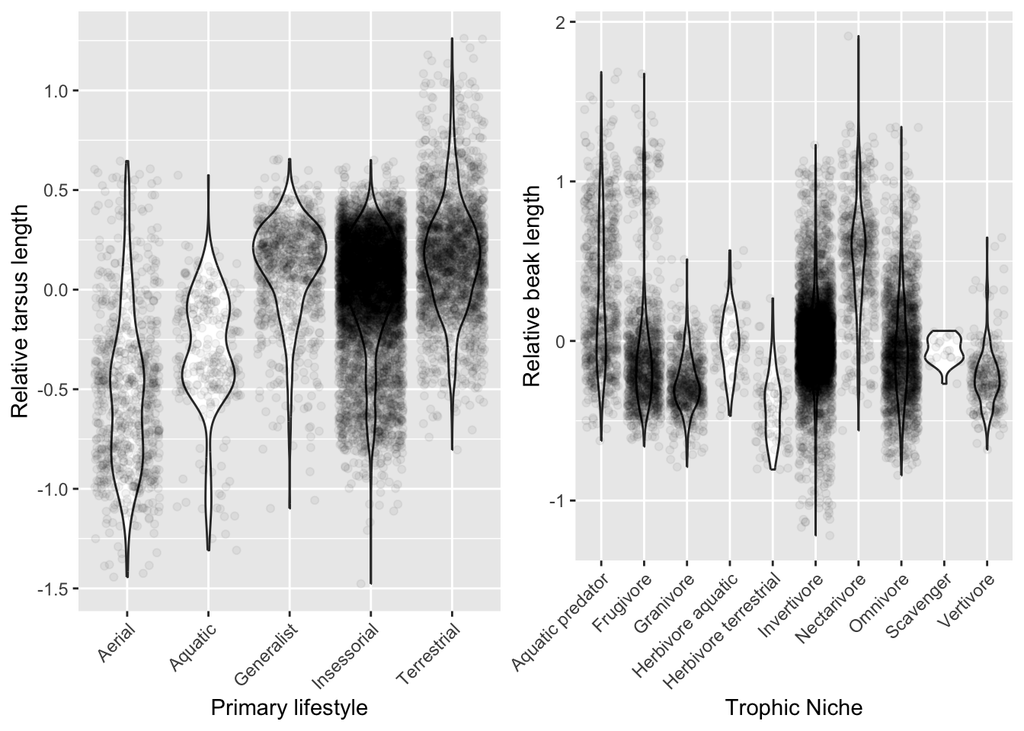

```r
# Relative tarsus length vs Primary.Lifestyle
p1 <- ggplot(data = d %>%
    drop_na(Primary.Lifestyle), aes(x = Primary.Lifestyle, y = rel_TL)) +
  geom_violin() + # or geom_boxplot()
  geom_jitter(alpha = 0.05) + # makes the dots more transparent
  theme(axis.text.x = element_text(angle = 45, hjust = 1)) +
  xlab("Primary lifestyle") + ylab("Relative tarsus length")

# Relative beak length vs Trophic.Niche
p2 <- ggplot(data = d %>%
    drop_na(Trophic.Niche), aes(x = Trophic.Niche, y = rel_BL)) +
  geom_violin() + # or geom_boxplot()
  geom_jitter(alpha = 0.05) + # makes the dots more transparent) +
  theme(axis.text.x = element_text(angle = 45, hjust = 1)) +
  xlab("Trophic Niche") + ylab("Relative beak length")

plot_grid(p1, p2, nrow = 1)
```

#### Step 3

- Run an ANOVA analyses to look at the association between geographic range size and the variable Migration. You should first drop those observations for which Migration is not scored and also look at the distribution of the variable Range.Size to decide whether and how it might need to be transformed. Based on the global model, is range size associated with form of migration? How much of the variance in your measure of range size is associated with Migration behavior style?
  - Based on the global model, range size is associated with the form of migration since the F stastistic is significant (p < 2e-16). As determined by the R-squared value, 8.67% of the varition in log(range size) is associated with Migration behavior style.
- Given the regression coefficients returned in output of the model, which Migration categor(ies) are different than the reference level? What level is the reference level? Relevel and assess differences among the remaining pair of Migration categories. Also conduct a post-hoc Tukey Honest Significant Differences test to also evaluate which Migration categories differ “significantly” from one another (see Module 20).
  - Migration level 3 is the reference level. Migration levels 1 and 2 are both different from Migration level 3. After releveling and making Migration level 1 the reference level, we can see that Migration level 1 is also different from Migration level 3. This indicates that all three migration levels are different from each other.
  - Tukey test confirms that migration levels are distinct from one another.

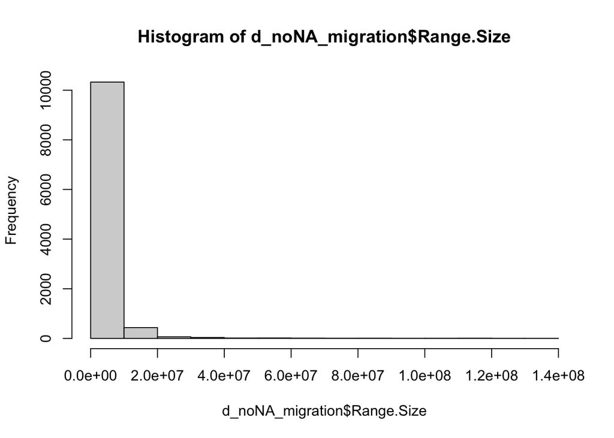

```r
# Look at the distribution of range size
d_noNA_migration <- d %>%
    drop_na(Migration)
hist(d_noNA_migration$Range.Size) # this needs to be transformed
```

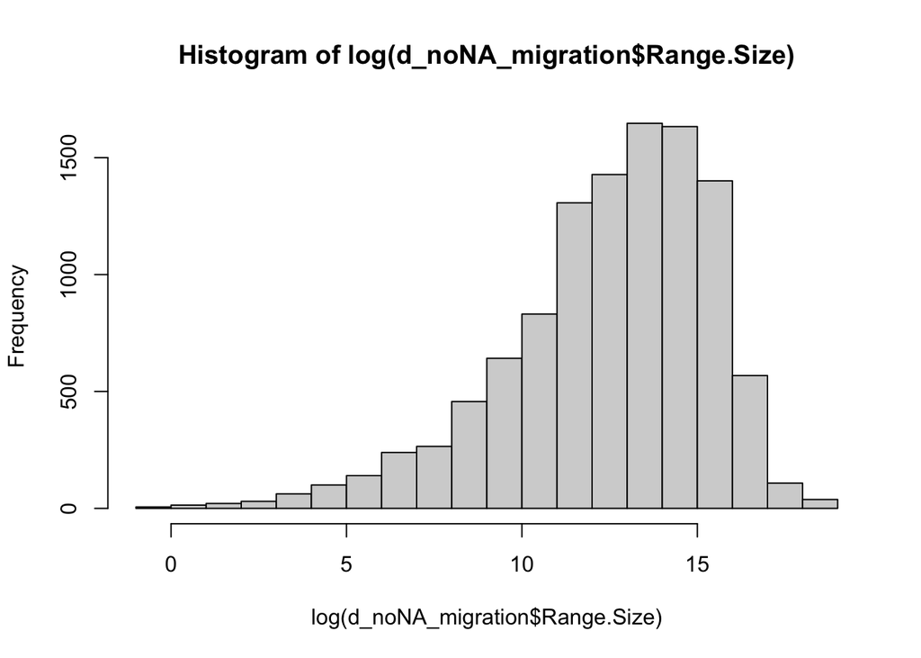

```r
hist(log(d_noNA_migration$Range.Size)) # better!
```

```r
# lm() can be used to run ANOVAs
m1 <- lm(logRS ~ Migration, data = d_noNA_migration)
summary(m1)
```

```
##
## Call:
## lm(formula = logRS ~ Migration, data = d_noNA_migration)
##
## Residuals:
##      Min       1Q   Median       3Q      Max
## -14.5710  -1.4521   0.4357   1.9763   5.9271
##
## Coefficients:
##             Estimate Std. Error t value Pr(>|t|)
## (Intercept) 14.55082    0.08896 163.568  < 2e-16 ***
## Migration2  -0.73233    0.12015  -6.095 1.13e-09 ***
## Migration1  -2.51702    0.09380 -26.834  < 2e-16 ***
## ---
## Signif. codes:  0 '***' 0.001 '**' 0.01 '*' 0.05 '.' 0.1 ' ' 1
##
## Residual standard error: 2.785 on 10934 degrees of freedom
##   (49 observations deleted due to missingness)
## Multiple R-squared:  0.0869, Adjusted R-squared:  0.08674
## F-statistic: 520.3 on 2 and 10934 DF,  p-value: < 2.2e-16
```

```r
# just to compare for fun
m1_aov <- aov(logRS ~ Migration, data = d_noNA_migration)
summary(m1_aov)
```

```
##                Df Sum Sq Mean Sq F value Pr(>F)
## Migration       2   8071    4035   520.3 <2e-16 ***
## Residuals   10934  84798       8
## ---
## Signif. codes:  0 '***' 0.001 '**' 0.01 '*' 0.05 '.' 0.1 ' ' 1
## 49 observations deleted due to missingness
```

```r
# Relevel
d_noNA_migration <- d_noNA_migration %>%
    mutate(Migration = relevel(Migration, ref = "1"))
m2 <- lm(logRS ~ Migration, data = d_noNA_migration)
summary(m2)
```

```
##
## Call:
## lm(formula = logRS ~ Migration, data = d_noNA_migration)
##
## Residuals:
##      Min       1Q   Median       3Q      Max
## -14.5710  -1.4521   0.4357   1.9763   5.9271
##
## Coefficients:
##             Estimate Std. Error t value Pr(>|t|)
## (Intercept) 12.03381    0.02974  404.62   <2e-16 ***
## Migration3   2.51702    0.09380   26.83   <2e-16 ***
## Migration2   1.78469    0.08606   20.74   <2e-16 ***
## ---
## Signif. codes:  0 '***' 0.001 '**' 0.01 '*' 0.05 '.' 0.1 ' ' 1
##
## Residual standard error: 2.785 on 10934 degrees of freedom
##   (49 observations deleted due to missingness)
## Multiple R-squared:  0.0869, Adjusted R-squared:  0.08674
## F-statistic: 520.3 on 2 and 10934 DF,  p-value: < 2.2e-16
```

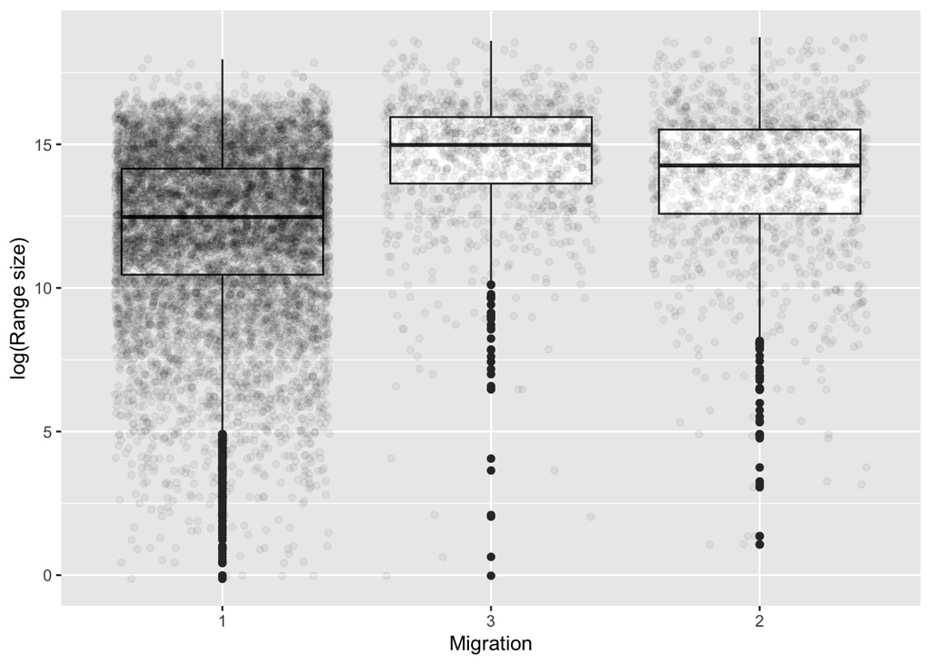

```r
ggplot(d_noNA_migration,
       aes(x = as.factor(Migration), y = logRS)) +
  geom_boxplot() +
  geom_jitter(alpha = 0.05) +
  xlab("Migration") + ylab("log(Range size)")
```

```r
# Tukey testin
RS_Mig_Tukey <- TukeyHSD(m1_aov, which = "Migration", conf.level = 0.95)
RS_Mig_Tukey
```

```
##   Tukey multiple comparisons of means
##     95% family-wise confidence level
##
## Fit: aov(formula = logRS ~ Migration, data = d_noNA_migration)
##
## $Migration
##           diff       lwr       upr p adj
## 2-3 -0.7323266 -1.013964 -0.450689     0
## 1-3 -2.5170168 -2.736883 -2.297150     0
## 1-2 -1.7846901 -1.986428 -1.582952     0
```

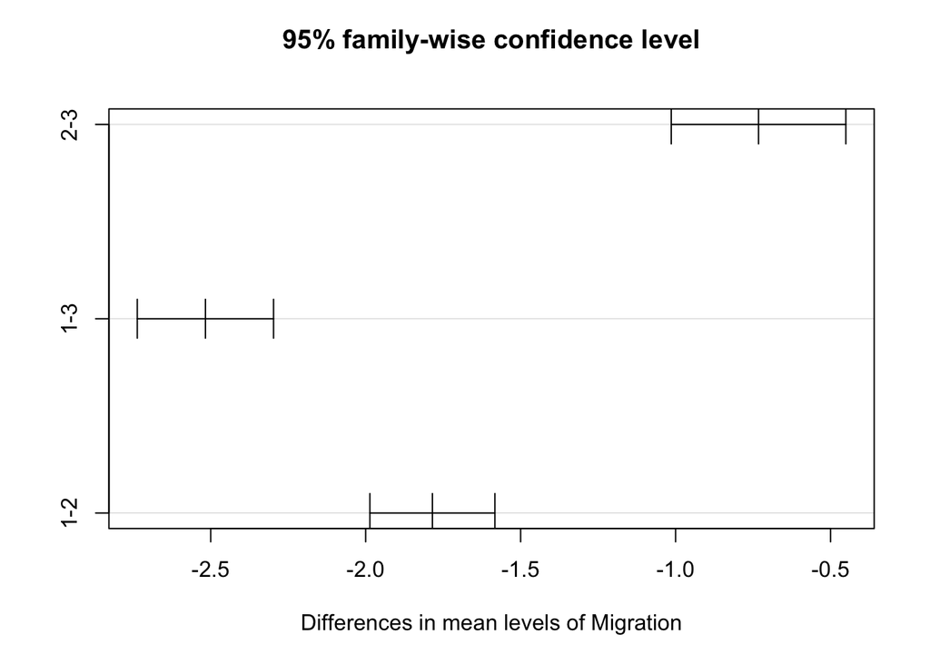

```r
plot(RS_Mig_Tukey)
```

#### Step 4

- Winnow your original data to just consider birds from the Infraorder “Passeriformes” (song birds).
- Run separate one-factor ANOVA analyses to look at the association between [1] relative beak length and Primary.Lifestyle and between [2] relative beak length and Trophic.Level. In doing so…
  - Make boxplots of response variable by each predictor and by the combination of predictors.
  - Run linear models for each predictor separately and interpret the model output.
    - Relative beak length is significantly associated with both primary lifestyle and trophic level. P values for all variables are significant.

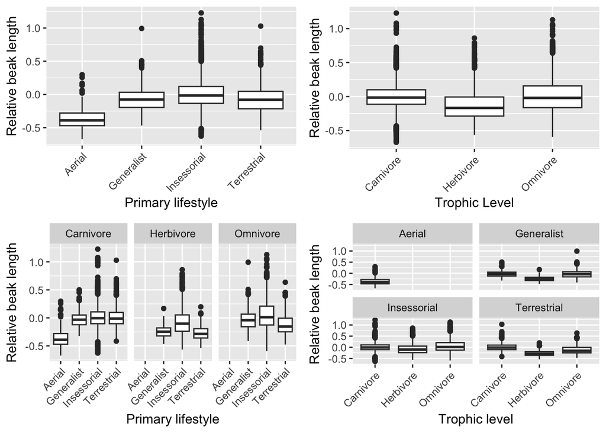

```r
# Winnow data to just passiformes
d_pass <- d %>%
    filter(Order1 == "Passeriformes")

# Running one-factor ANOVA
# Primary lifestyle x relative beak length
p1 <- ggplot(data = d_pass, aes(x = Primary.Lifestyle, y = rel_BL)) +
  geom_boxplot() +
  theme(axis.text.x = element_text(angle = 45, hjust = 1)) +
  xlab("Primary lifestyle") + ylab("Relative beak length")

# Trophic level x relative beak length
p2 <- ggplot(data = d_pass, aes(x = Trophic.Level, y = rel_BL)) +
  geom_boxplot() +
  theme(axis.text.x = element_text(angle = 45, hjust = 1)) +
  xlab("Trophic Level") + ylab("Relative beak length")

# Primary lifestyle x relative beak length, divided by trophic level
p3 <- ggplot(data = d_pass, aes(x = Primary.Lifestyle, y = rel_BL)) +
  geom_boxplot() +
  facet_wrap(~Trophic.Level) +
  theme(axis.text.x = element_text(angle = 45, hjust = 1)) +
  xlab("Primary lifestyle") + ylab("Relative beak length")

# Trophic level x relative beak length, divided by primary lifestyle
p4 <- ggplot(data = d_pass, aes(x = Trophic.Level, y = rel_BL)) +
  geom_boxplot() +
  facet_wrap(~Primary.Lifestyle) +
  theme(axis.text.x = element_text(angle = 45, hjust = 1)) +
  xlab("Trophic level") + ylab("Relative beak length")


library(ggpubr)
ggarrange(p1, p2, p3, p4,
          labels = NULL,
          ncol = 2, nrow = 2)
```

```r
detach(package:ggpubr)

# Running linear models lm()
m5 <- lm(rel_BL ~ Primary.Lifestyle, data = d_pass)
m6 <- lm(rel_BL ~ Trophic.Level, data = d_pass)

summary(m5)
```

```
##
## Call:
## lm(formula = rel_BL ~ Primary.Lifestyle, data = d_pass)
##
## Residuals:
##     Min      1Q  Median      3Q     Max
## -0.6314 -0.1380 -0.0172  0.1118  1.2241
##
## Coefficients:
##                              Estimate Std. Error t value Pr(>|t|)
## (Intercept)                  -0.34950    0.02158  -16.19   <2e-16 ***
## Primary.LifestyleGeneralist   0.27926    0.02306   12.11   <2e-16 ***
## Primary.LifestyleInsessorial  0.35342    0.02181   16.20   <2e-16 ***
## Primary.LifestyleTerrestrial  0.27924    0.02249   12.42   <2e-16 ***
## ---
## Signif. codes:  0 '***' 0.001 '**' 0.01 '*' 0.05 '.' 0.1 ' ' 1
##
## Residual standard error: 0.2158 on 6610 degrees of freedom
## Multiple R-squared:  0.05581,    Adjusted R-squared:  0.05538
## F-statistic: 130.2 on 3 and 6610 DF,  p-value: < 2.2e-16
```

```r
summary(m6)
```

```
##
## Call:
## lm(formula = rel_BL ~ Trophic.Level, data = d_pass)
##
## Residuals:
##      Min       1Q   Median       3Q      Max
## -0.67045 -0.13692 -0.02063  0.11129  1.23116
##
## Coefficients:
##                         Estimate Std. Error t value Pr(>|t|)
## (Intercept)            -0.003170   0.003501  -0.906  0.36518
## Trophic.LevelHerbivore -0.118713   0.006956 -17.066  < 2e-16 ***
## Trophic.LevelOmnivore   0.017902   0.006606   2.710  0.00675 **
## ---
## Signif. codes:  0 '***' 0.001 '**' 0.01 '*' 0.05 '.' 0.1 ' ' 1
##
## Residual standard error: 0.2165 on 6611 degrees of freedom
## Multiple R-squared:  0.05001,    Adjusted R-squared:  0.04972
## F-statistic:   174 on 2 and 6611 DF,  p-value: < 2.2e-16
```

#### Step 5

- Run a two-factor model to look at the association between relative beak length and both Primary.Lifestyle and Trophic.Level among the passeriforms. Based on the model output, what would you conclude about how relative beak length is related to these two variables?
  - Both trophic level and primary lifestyle are predictive of relative beak length. This combination accounts for 10.9% of the variance in relative beak length (based on adjusted R-squared).

```r
m7 <- lm(rel_BL ~ Primary.Lifestyle + Trophic.Level, data = d_pass)
summary(m7)
```

```
##
## Call:
## lm(formula = rel_BL ~ Primary.Lifestyle + Trophic.Level, data = d_pass)
##
## Residuals:
##      Min       1Q   Median       3Q      Max
## -0.65365 -0.13329 -0.02284  0.10274  1.20180
##
## Coefficients:
##                               Estimate Std. Error t value Pr(>|t|)
## (Intercept)                  -0.349502   0.020958 -16.677   <2e-16 ***
## Primary.LifestyleGeneralist   0.301517   0.022582  13.352   <2e-16 ***
## Primary.LifestyleInsessorial  0.375698   0.021295  17.642   <2e-16 ***
## Primary.LifestyleTerrestrial  0.302119   0.021942  13.769   <2e-16 ***
## Trophic.LevelHerbivore       -0.126397   0.006761 -18.695   <2e-16 ***
## Trophic.LevelOmnivore         0.012140   0.006450   1.882   0.0599 .
## ---
## Signif. codes:  0 '***' 0.001 '**' 0.01 '*' 0.05 '.' 0.1 ' ' 1
##
## Residual standard error: 0.2096 on 6608 degrees of freedom
## Multiple R-squared:   0.11,  Adjusted R-squared:  0.1093
## F-statistic: 163.4 on 5 and 6608 DF,  p-value: < 2.2e-16
```

```r
# get ANOVA's R-squared via summary output of the corresponding linear model
m7_aov <- lm(rel_BL ~ Trophic.Level + Primary.Lifestyle,
              data = d_pass)
summary(m7_aov)
```

```
##
## Call:
## lm(formula = rel_BL ~ Trophic.Level + Primary.Lifestyle, data = d_pass)
##
## Residuals:
##      Min       1Q   Median       3Q      Max
## -0.65365 -0.13329 -0.02284  0.10274  1.20180
##
## Coefficients:
##                               Estimate Std. Error t value Pr(>|t|)
## (Intercept)                  -0.349502   0.020958 -16.677   <2e-16 ***
## Trophic.LevelHerbivore       -0.126397   0.006761 -18.695   <2e-16 ***
## Trophic.LevelOmnivore         0.012140   0.006450   1.882   0.0599 .
## Primary.LifestyleGeneralist   0.301517   0.022582  13.352   <2e-16 ***
## Primary.LifestyleInsessorial  0.375698   0.021295  17.642   <2e-16 ***
## Primary.LifestyleTerrestrial  0.302119   0.021942  13.769   <2e-16 ***
## ---
## Signif. codes:  0 '***' 0.001 '**' 0.01 '*' 0.05 '.' 0.1 ' ' 1
##
## Residual standard error: 0.2096 on 6608 degrees of freedom
## Multiple R-squared:   0.11,  Adjusted R-squared:  0.1093
## F-statistic: 163.4 on 5 and 6608 DF,  p-value: < 2.2e-16
```

#### Step 6

- Finally, run an additional two-way model with the same dataset and predictors, but adding the possibility of an interaction term. To do this, you should modify your model formula using the colon operator (:) to specify the interaction, e.g., relative beak length ~ Primary.Lifestyle + Trophic.Level + Primary.Lifestyle:Trophic.Level. Based on the model output, what would you now conclude about how relative beak length is related to these two variables?
  - Trophic.Level and Primary.Lifestyle are predictive of relative beak length as well as interaction between these two predictors. The three predictors account for 13.5% of the variance in beak length

```r
m8 <- aov(rel_BL ~ Trophic.Level + Primary.Lifestyle + Trophic.Level:Primary.Lifestyle,
              data = d_pass)
summary(m8)
```

```
##                                   Df Sum Sq Mean Sq F value Pr(>F)
## Trophic.Level                      2  16.31   8.154  191.08 <2e-16 ***
## Primary.Lifestyle                  3  19.57   6.523  152.84 <2e-16 ***
## Trophic.Level:Primary.Lifestyle    4   8.41   2.102   49.26 <2e-16 ***
## Residuals                       6604 281.83   0.043
## ---
## Signif. codes:  0 '***' 0.001 '**' 0.01 '*' 0.05 '.' 0.1 ' ' 1
```

```r
m9 <- lm(rel_BL ~ Trophic.Level + Primary.Lifestyle + Trophic.Level:Primary.Lifestyle,
              data = d_pass)
summary(m9)
```

```
##
## Call:
## lm(formula = rel_BL ~ Trophic.Level + Primary.Lifestyle + Trophic.Level:Primary.Lifestyle,
##     data = d_pass)
##
## Residuals:
##      Min       1Q   Median       3Q      Max
## -0.64623 -0.12836 -0.02078  0.10070  1.21924
##
## Coefficients: (2 not defined because of singularities)
##                                                     Estimate Std. Error t value
## (Intercept)                                         -0.34950    0.02066 -16.918
## Trophic.LevelHerbivore                              -0.27502    0.01562 -17.608
## Trophic.LevelOmnivore                               -0.11080    0.01550  -7.150
## Primary.LifestyleGeneralist                          0.33010    0.02367  13.948
## Primary.LifestyleInsessorial                         0.35826    0.02104  17.031
## Primary.LifestyleTerrestrial                         0.35714    0.02210  16.162
## Trophic.LevelHerbivore:Primary.LifestyleGeneralist   0.05033    0.02584   1.948
## Trophic.LevelOmnivore:Primary.LifestyleGeneralist    0.09898    0.02351   4.210
## Trophic.LevelHerbivore:Primary.LifestyleInsessorial  0.20115    0.01750  11.494
## Trophic.LevelOmnivore:Primary.LifestyleInsessorial   0.15527    0.01726   8.996
## Trophic.LevelHerbivore:Primary.LifestyleTerrestrial       NA         NA      NA
## Trophic.LevelOmnivore:Primary.LifestyleTerrestrial        NA         NA      NA
##                                                     Pr(>|t|)
## (Intercept)                                          < 2e-16 ***
## Trophic.LevelHerbivore                               < 2e-16 ***
## Trophic.LevelOmnivore                               9.61e-13 ***
## Primary.LifestyleGeneralist                          < 2e-16 ***
## Primary.LifestyleInsessorial                         < 2e-16 ***
## Primary.LifestyleTerrestrial                         < 2e-16 ***
## Trophic.LevelHerbivore:Primary.LifestyleGeneralist    0.0515 .
## Trophic.LevelOmnivore:Primary.LifestyleGeneralist   2.59e-05 ***
## Trophic.LevelHerbivore:Primary.LifestyleInsessorial  < 2e-16 ***
## Trophic.LevelOmnivore:Primary.LifestyleInsessorial   < 2e-16 ***
## Trophic.LevelHerbivore:Primary.LifestyleTerrestrial       NA
## Trophic.LevelOmnivore:Primary.LifestyleTerrestrial        NA
## ---
## Signif. codes:  0 '***' 0.001 '**' 0.01 '*' 0.05 '.' 0.1 ' ' 1
##
## Residual standard error: 0.2066 on 6604 degrees of freedom
## Multiple R-squared:  0.1358, Adjusted R-squared:  0.1346
## F-statistic: 115.3 on 9 and 6604 DF,  p-value: < 2.2e-16
```

#### Step 7

- Use the interaction.plot() function to visualize the interaction between Primary.Lifestyle and Trophic.Level

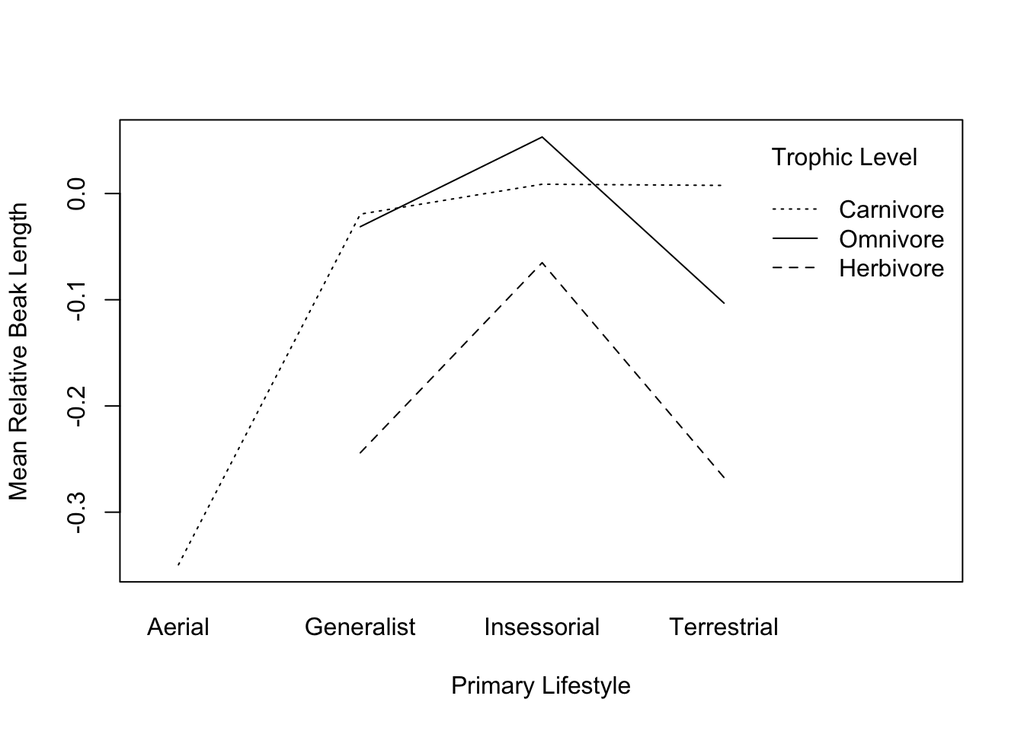

```r
p5 <- interaction.plot(
  x.factor = d_pass$Primary.Lifestyle,
  xlab = "Primary Lifestyle",
  trace.factor = d_pass$Trophic.Level,
  trace.label = "Trophic Level",
  response = d_pass$rel_BL,
  fun = base::mean, # make sure we use {base} version
  ylab = "Mean Relative Beak Length"
)
```

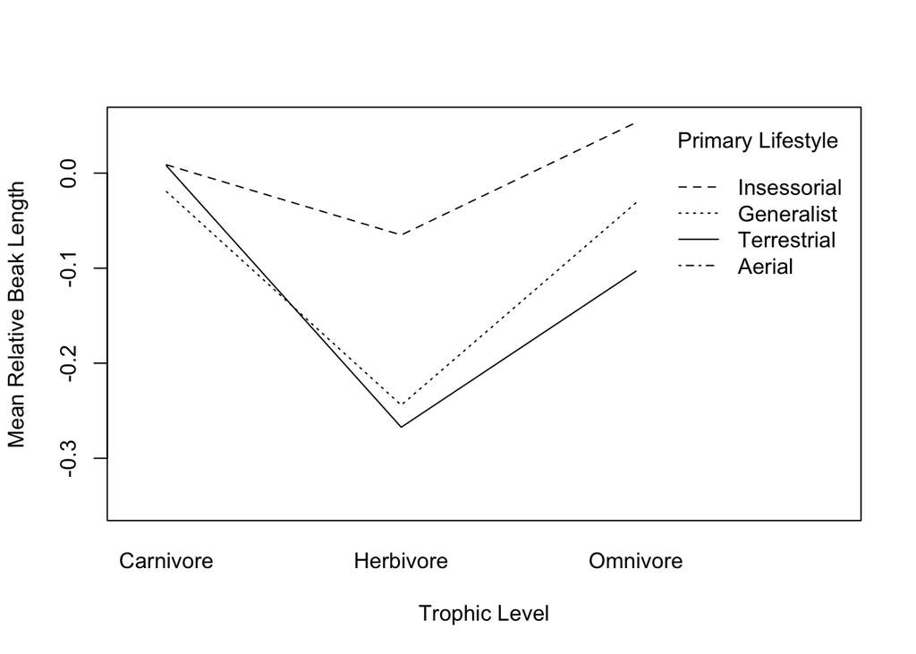

```r
p6 <- interaction.plot(
  x.factor = d_pass$Trophic.Level,
  xlab = "Trophic Level",
  trace.factor = d_pass$Primary.Lifestyle,
  trace.label = "Primary Lifestyle",
  response = d_pass$rel_BL,
  fun = base::mean, # make sure we use {base} version
  ylab = "Mean Relative Beak Length"
)
```

#### Additional Steps

```r
# Checking ratio of variances
ratio_relBL <- d_pass %>%
    group_by(Trophic.Level) %>%
    summarize(sd = sd(rel_BL, na.rm = TRUE)) %>%
    pull(sd)
ratio_relBL <- max(ratio_relBL)/min(ratio_relBL)
ratio_relBL
```

```
## [1] 1.336194
```

```r
ratio_RS <- d_noNA_migration %>%
  group_by(Migration) %>%
  summarize(sd = sd(logRS, na.rm = TRUE)) %>%
  pull(sd)
ratio_RS <- max(ratio_RS)/min(ratio_RS)
ratio_RS
```

```
## [1] 1.332764
```

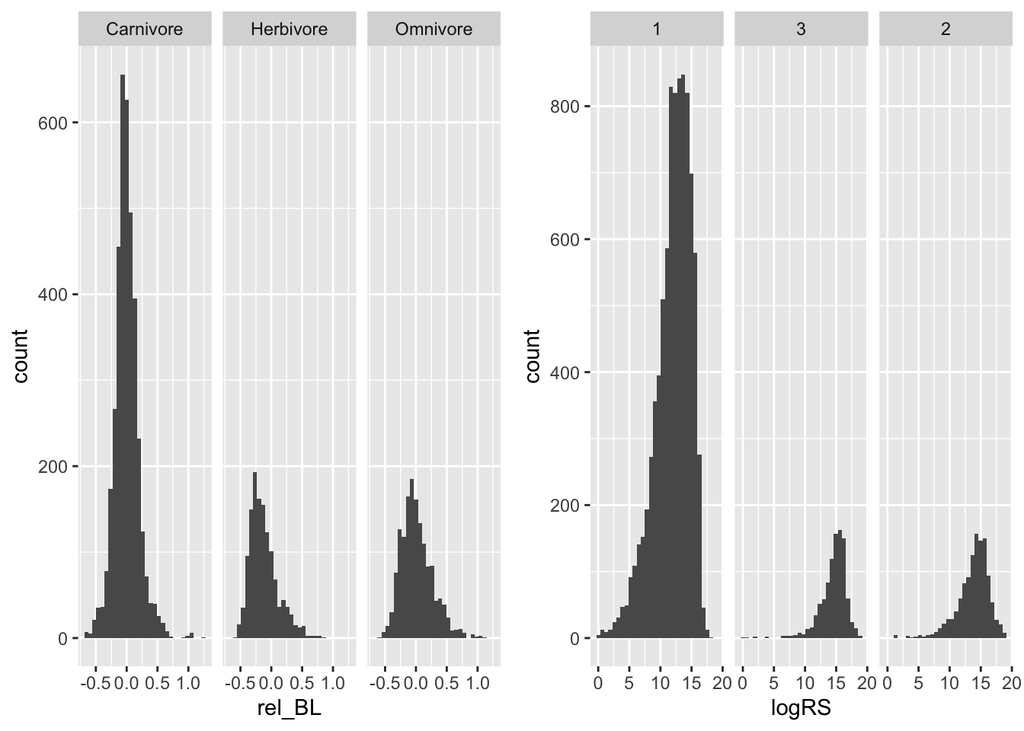

```r
# Checking counts
p1 <- ggplot(data = d_pass, aes(x = rel_BL)) +
  geom_histogram() +
  facet_wrap(~Trophic.Level)

p2 <- ggplot(data = d_noNA_migration, aes(x = logRS)) +
  geom_histogram() +
  facet_wrap(~Migration)

plot_grid(p1, p2)
```

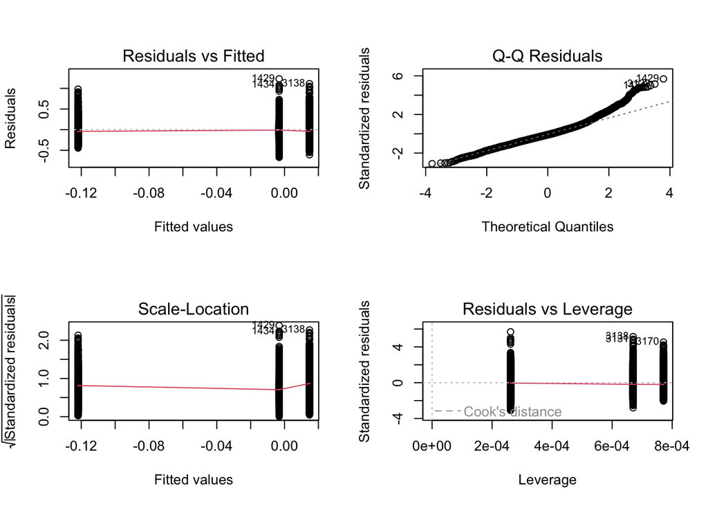

```r
# Visual checks by plotting the lm()
# For ease, I am going to just remake the variables although this has been calculated previously.
m1 <- lm(data = d_pass, rel_BL ~ Trophic.Level)

par(mfrow = c(2, 2))
plot(m1)
```

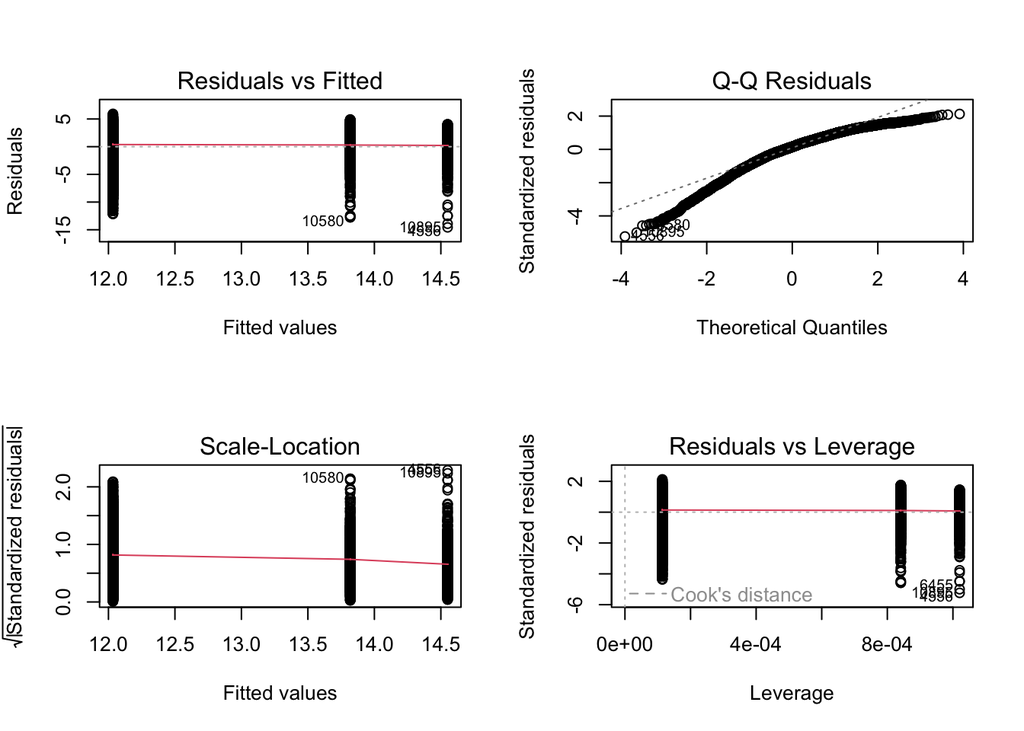

```r
m2 <- lm(data = d_noNA_migration, logRS ~ Migration)
par(mfrow = c(2, 2))
plot(m2)
```